# Importing libraries

```python
import cv2
import numpy as np
import requests
import matplotlib.pyplot as plt
import matplotlib.image as mpimg
import sys
import datetime
from tensorflow import keras
from tensorflow.keras.models import Model
import tensorflow as tf
```

**`import cv2`** : Used for image and video processing, particularly for pre-processing images.  
**`import numpy as np`** : Used to manipulate numerical arrays, useful for image data.  
**`import requests`**: Used to send HTTP requests, enabling data to be downloaded from a URL.  
**`import matplotlib.pyplot as plt`** : Used to create visualisations such as graphs or to display images.  
**`import matplotlib.image as mpimg`**: Loads images with Matplotlib.  
**`import sys`** : Allows access to variables and functions in the Python environment, such as argument or error handling.  
**`import datetime`** : Allows you to manipulate dates and times, useful for adding timestamps.  
**`from tensorflow import keras`** : Used to load or create deep learning models with Keras.  
**`from tensorflow.keras.models import Model`** : Used to define or manipulate Keras models.  
**`import tensorflow as tf`** : Provides the necessary tools for training and executing machine learning models.

# Download and display

```
Shape of the image (163583,)
```

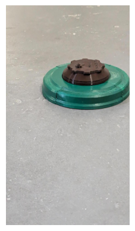

```
Shape of the image (45055,)
```

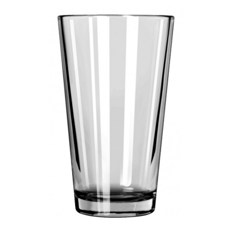

```python
url_mine = r'https://github.com/WangAline/projet_VE/raw/main/image_mine.jpg'
resp = requests.get(url_mine, stream=True).raw
image_array_mine = np.asarray(bytearray(resp.read()), dtype="uint8")
print(f'Shape of the image {image_array_mine.shape}')
image_mine = cv2.imdecode(image_array_mine, cv2.IMREAD_COLOR)
plt.axis('off')
plt.imshow(cv2.cvtColor(image_mine, cv2.COLOR_BGR2RGB))
plt.show()

url_nomine = r'https://github.com/WangAline/projet_VE/raw/main/image_Nomine.jpg'
resp = requests.get(url_nomine, stream=True).raw
image_array_nomine = np.asarray(bytearray(resp.read()), dtype="uint8")
print(f'Shape of the image {image_array_nomine.shape}')
image_nomine = cv2.imdecode(image_array_nomine, cv2.IMREAD_COLOR)
plt.axis('off')
plt.imshow(cv2.cvtColor(image_nomine, cv2.COLOR_BGR2RGB))
plt.show()
```

This block of code allows you to:

- Download two images from remote URLs.
- Convert them into arrays for manipulation with OpenCV.
- Display the images using Matplotlib.

# Convert an image to greyscale

```
(40, 40, 3)
(40, 40)
255  255  255  255  255  255  255  255  255  255  255  255  255  255  255  255  255  255  255  255  255  255  255  255  255  255  255  255  255  255  255  255  255  255  255  255  255  255  255  255
255  255  255  255  255  255  255  255  255  255  255  255  255  255  255  255  255  255  255  255  255  255  255  255  255  255  255  255  255  255  255  255  255  255  255  255  255  255  255  255
255  255  255  255  255  255  255  255  255  255  255  255  255  255  255  255  255  255  255  255  255  255  255  255  255  255  255  255  255  255  255  255  255  255  255  255  255  255  255  255
255  255  255  255  255  255  255  255  255  255  255  255  255  255  255  255  255  255  255  255  255  255  255  255  255  255  255  255  255  255  255  255  255  255  255  255  255  255  255  255
255  255  255  255  255  255  255  255  255  255  255  255  255  255  255  255  255  255  255  255  255  255  255  255  255  255  255  255  255  255  255  255  255  255  255  255  255  255  255  255
255  255  255  255  255  255  255  255  255  255  255  255  255  255  255  255  255  255  255  255  255  255  255  255  255  255  255  255  255  255  255  255  255  255  255  255  255  255  255  255
255  255  255  255  255  255  255  255  255  255  255  255  255  255  255  255  255  255  255  255  255  255  255  255  255  255  255  255  255  255  255  255  255  255  255  255  255  255  255  255
255  255  255  255  255  255  255  255  255  255  255  255  255  255  255  255  255  255  255  255  255  255  255  255  255  255  255  255  255  255  255  255  255  255  255  255  255  255  255  255
255  255  255  255  255  255  255  255  255  255  255  255  255  255  255  255  255  255  255  255  255  255  255  255  255  255  255  255  255  255  255  255  255  255  255  255  255  255  255  255
255  255  255  255  255  255  255  255  255  255  255  255  255  255  255  255  255  255  255  255  255  255  255  255  255  255  255  255  255  255  255  255  255  255  255  255  255  255  255  255
255  255  255  255  255  255  255  255  255  255  255  255  255  255  255  255  255  255  255  255  255  000  000  000  000  000  000  000  000  000  000  255  255  255  255  255  255  255  255  255
255  255  255  255  255  255  255  255  255  255  255  255  255  255  255  255  255  255  255  000  000  000  000  000  000  000  000  000  000  000  000  000  000  255  255  255  255  255  255  255
255  255  255  255  255  255  255  255  255  255  255  255  255  255  255  255  255  255  000  000  000  000  000  000  000  000  000  000  000  000  000  000  000  000  255  255  255  255  255  255
```

[output cut: 27 more lines]

[figure not shown]

```python
res = cv2.resize(image_mine , dsize=(40,40), interpolation=cv2.INTER_CUBIC)
print(res.shape)
res = cv2.cvtColor(res,cv2.COLOR_RGB2GRAY)
print(res.shape)
res = cv2.threshold(res, 127, 255, cv2.THRESH_BINARY)[1]
d = res
for row in range(0,40):
    for col in range(0,40):
        print('%03d ' %d[row][col],end=' ')
    print('')
plt.imshow(cv2.cvtColor(res, cv2.COLOR_BGR2RGB))
plt.axis('off')
plt.show()
```

This code processes the image to :

- Resize it to 40x40 pixels.
- Convert it to greyscale.
- Binarise it.
- Scan each pixel to display its binary values.
- Display the binary image.

# Libraries for training preparation

- Data processing (for example, extracting compressed files).
- Path management for locating and loading data.
- Training or using TensorFlow models.

```python
import pathlib
import os
import tensorflow as tf
import zipfile
```

Download a ZIP file, extract it and define the path for the extracted data

```python
# Download ZIP file
data_dir = tf.keras.utils.get_file(
    "dataset.zip",
    "https://github.com/WangAline/projet_VE/raw/main/dataset/dataset.zip",
    extract=False
)

# Extract ZIP file
with zipfile.ZipFile(data_dir, 'r') as zip_ref:
    zip_ref.extractall('/content/datasets')

# Definition of extracted data path
data_dir = pathlib.Path('/content/datasets/dataset')

# Path display
print(data_dir)
print(os.path.abspath(data_dir))
```

```
Downloading data from https://github.com/WangAline/projet_VE/raw/main/dataset/dataset.zip
27313644/27313644 ━━━━━━━━━━━━━━━━━━━━ 0s 0us/step
/content/datasets/dataset
/content/datasets/dataset
```

```python
batch_size = 16
image_heigth=300
image_width=300
```

These variables define key parameters for training the model:

1. `batch_size = 16`: Number of images processed at the same time. A small batch reduces memory but can make the optimisation less stable.
2. `image_height = 300` and `image_width = 300`: Image resizing dimensions before training. Used to standardise the size of model inputs.

# Preparing data for training

```python
train_data=tf.keras.preprocessing.image_dataset_from_directory(
    data_dir,
    validation_split=0.2,
    subset="training",
    seed=42,
    image_size=(image_heigth,image_width),
    batch_size=batch_size,

)
```

```
Found 260 files belonging to 2 classes.
Using 208 files for training.
```

```python
val_data=tf.keras.preprocessing.image_dataset_from_directory(
    data_dir,
    validation_split=0.2,
    subset="validation",
    seed=42,
    image_size=(image_heigth,image_width),
    batch_size=batch_size,

)
```

```
Found 260 files belonging to 2 classes.
Using 52 files for validation.
```

```python
class_names=val_data.class_names
print(class_names)
```

```
['Mines', 'No mines']
```

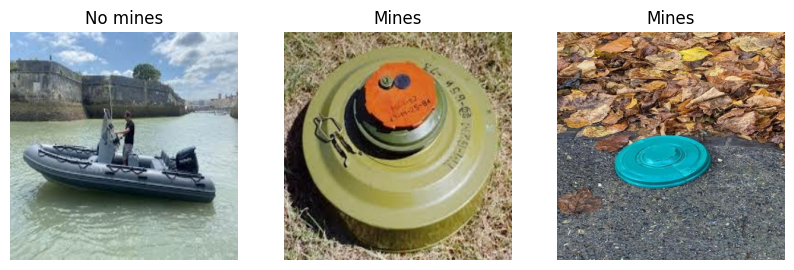

```python
plt.figure(figsize=(10, 10))

for images, labels in train_data.take(1):
    for i in range(3):
        ax = plt.subplot(1, 3, i+1)
        plt.imshow(images[i].numpy().astype("uint8"))
        plt.title(class_names[labels[i].numpy()])
        plt.axis("off")
plt.show()
```

# Building the model

The layers module of tensorflow.keras contains a wide range of layers that can be used to build a neural network model in TensorFlow/Keras. These layers are the basic elements which define the structure of the model.

```python
from tensorflow.keras import layers
```

```python
num_classes = 2

model = tf.keras.Sequential([
    layers.Rescaling(1./255),
    layers.Conv2D(128,4, activation='relu'),
    layers.MaxPooling2D(),
    layers.Conv2D(64,4, activation='relu'),
    layers.MaxPooling2D(),
    layers.Conv2D(32,4, activation='relu'),
    layers.MaxPooling2D(),
    layers.Conv2D(16,4, activation='relu'),
    layers.MaxPooling2D(),
    layers.Flatten(),
    layers.Dense(64,activation='relu'),
    layers.Dense(num_classes, activation='softmax')

])
```

```python
model.compile(optimizer='adam',
              loss=tf.losses.SparseCategoricalCrossentropy(from_logits=True),
  metrics=['accuracy'],)

logdir="logs"

tensorboard_callback = tf.keras.callbacks.TensorBoard(
    log_dir=logdir,
    histogram_freq=1,
    write_images=True
)
```

The code creates a convolutional neural network model to classify images into two categories (mines and no mines). It normalizes the images, applies convolution and pooling layers to extract features, then flattens them before passing them to dense layers. The model is compiled with the `Adam` optimizer and the `SparseCategoricalCrossentropy` loss function. A `TensorBoard` callback is configured to visualise the training.

```python
model.fit(
  train_data,
  validation_data=val_data,
  epochs=5,
  callbacks=[tensorboard_callback]
)
```

```
13/13 ━━━━━━━━━━━━━━━━━━━━ 8s 307ms/step - accuracy: 0.4801 - loss: 0.7106 - val_accuracy: 0.5000 - val_loss: 0.6904
13/13 ━━━━━━━━━━━━━━━━━━━━ 2s 158ms/step - accuracy: 0.6036 - loss: 0.6771 - val_accuracy: 0.7500 - val_loss: 0.6629
13/13 ━━━━━━━━━━━━━━━━━━━━ 2s 148ms/step - accuracy: 0.7420 - loss: 0.6258 - val_accuracy: 0.7308 - val_loss: 0.5598
13/13 ━━━━━━━━━━━━━━━━━━━━ 2s 157ms/step - accuracy: 0.7601 - loss: 0.5655 - val_accuracy: 0.8654 - val_loss: 0.4707
13/13 ━━━━━━━━━━━━━━━━━━━━ 3s 170ms/step - accuracy: 0.7922 - loss: 0.4863 - val_accuracy: 0.8654 - val_loss: 0.4040
```

```
<keras.src.callbacks.history.History at 0x7b7468f58eb0>
```

Upload widget is only available when the cell has been executed in the current browser session. Please rerun this cell to enable.

```
Saving IMG_1.jpg to IMG_1 (2).jpg
```

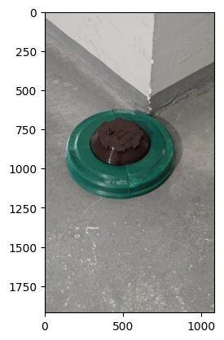

```
1/1 ━━━━━━━━━━━━━━━━━━━━ 0s 38ms/step
Probabilités de chaque classe: [[0.64680487 0.3531951 ]]
Classe prédite: 0
Mines
Mines!
```

```python
from google.colab import files
import cv2
import numpy as np
import matplotlib.pyplot as plt

# Loading the file for prediction
file_to_predict = files.upload()

for file_ in file_to_predict:
    # Read the colour image
    image_to_predict = cv2.imread(file_, cv2.IMREAD_COLOR)

    # Display the loaded image
    plt.imshow(cv2.cvtColor(image_to_predict, cv2.COLOR_BGR2RGB))
    plt.show()

    # Preparing the image for the model
    img_to_predict = np.expand_dims(cv2.resize(image_to_predict, (300, 300)), axis=0)

    # Use model.predict and np.argmax for prediction
    predictions = model.predict(img_to_predict)
    res = np.argmax(predictions, axis=-1)[0]  # Classe prédite (0 ou 1)

    # Displaying results
    print("Probabilités de chaque classe:", predictions)
    print("Classe prédite:", res)

    # Display the corresponding result
    print(class_names[res])
    if class_names[res] == 'Mines':
      plt.show()
      print("Mines!")
    else:
      plt.show()
      print("No Mine!")
```